# Tutorial 11 — Inter-Individual Variability and Virtual Populations

**Prerequisites:** Tutorials 01–10

A single simulation represents one hypothetical patient. Real phage therapy trials enrol tens to hundreds of patients who differ in bacterial burden, immune function, phage pharmacokinetics, and many other parameters. **Inter-individual variability (IIV)** modelling generates a *virtual patient population* (VPOP) that captures this heterogeneity, producing realistic distributions of outcomes.

**What you will learn**

1. IIV distributions: `Fixed`, `LogNormal`, `Normal`, `Uniform`
2. `IIVSpec` — mapping distributions to model parameters
3. `InitialConditions` and the `"ic."` path prefix for variable starting values
4. `VirtualPopulation` — generating 100–1000 patient-specific configs
5. `TrialRunner` — parallel batch simulation
6. Outcome metrics: `time_to_clearance`, `nadir_count`, `bacterial_auc`, `final_resistant_fraction`
7. `plot_trajectories`, `plot_metric_distributions`, `plot_time_to_event`

## 1 Imports

```python
import numpy as np
import matplotlib.pyplot as plt

from pbisim import (ModelBuilder, PBIModel, solve_ode,
                    Fixed, LogNormal, Normal, Uniform,
                    IIVSpec, InitialConditions, VirtualPopulation,
                    TrialRunner, default_metrics,
                    DoseEvent, DoseSchedule)
# Note: default_metrics() produces columns: time_to_clearance, nadir_count,
#       nadir_time, bacterial_auc, log_bacterial_auc, regrowth_time, etc.
from pbisim.analysis.population import (plot_trajectories,
                                        plot_metric_distributions,
                                        plot_time_to_event)

np.random.seed(42)
```

## 2 IIV distributions

pbisim provides four distribution types for varying parameters across patients:

| Distribution | Constructor | Use when |
| --- | --- | --- |
| `Fixed(v)` | constant — no variability | Reference parameter |
| `LogNormal(cv=...)` | right-skewed, always positive | PK rates, bacterial load |
| `Normal(mean, sd)` | symmetric, can be negative | Additive errors |
| `Uniform(lo, hi)` | uniform | Bounded parameters |

**Coefficient of variation (CV)** for `LogNormal`: CV ≈ σ in log-space. A CV of 0.3 means ±30% variability is typical. PK parameters commonly have CV = 30–50%; bacterial inoculum CV = 50–100% in clinical settings.

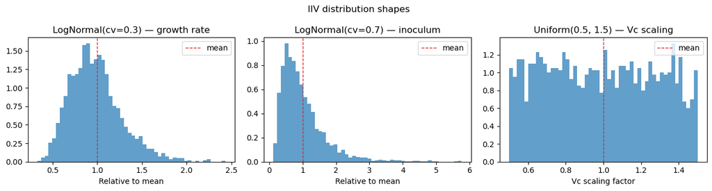

```python
rng = np.random.default_rng(42)
n_samples = 2000
fig, axes = plt.subplots(1, 3, figsize=(13, 3.5))

for ax, (label, dist, x_label) in zip(axes, [
    ("LogNormal(cv=0.3) — growth rate", LogNormal(cv=0.3), "Relative to mean"),
    ("LogNormal(cv=0.7) — inoculum",    LogNormal(cv=0.7), "Relative to mean"),
    ("Uniform(0.5, 1.5) — Vc scaling",  Uniform(0.5, 1.5), "Vc scaling factor"),
]):
    samples = [float(dist.sample(rng)) for _ in range(n_samples)]
    ax.hist(samples, bins=50, density=True, alpha=0.7, color="C0")
    ax.set(xlabel=x_label, title=label)
    ax.axvline(1.0, color="C3", ls="--", lw=1, label="mean")
    ax.legend()

plt.suptitle("IIV distribution shapes")
plt.tight_layout()
plt.show()
```

## 3 Defining IIV with `IIVSpec`

`IIVSpec` maps model parameter paths to `(distribution, transform)` pairs.

**Parameter paths** mirror `ModelConfig` field names. The special `"ic."` prefix maps to `InitialConditions` fields (initial bacterial count, phage count, etc.).

**Transform types:**

- `"multiplicative"`: sampled value multiplies the base value (use for rates)
- `"additive"`: sampled value is added to the base value (rare)

**Clinical variability modelled here:**

```python
iiv = IIVSpec({
    "growth_rates":     (LogNormal(cv=0.3), "multiplicative"),   # ±30% CV
    "adsorption_rates": (LogNormal(cv=0.4), "multiplicative"),   # ±40% CV
    "ic.B":             (LogNormal(cv=0.8), "multiplicative"),   # ±80% CV inoculum
})
print("IIV paths defined:")
for path, (dist, mode) in iiv.specs.items():
    print(f"  {path}: {type(dist).__name__}  ({mode})")
```

```
IIV paths defined:
  growth_rates: LogNormal  (multiplicative)
  adsorption_rates: LogNormal  (multiplicative)
  ic.B: LogNormal  (multiplicative)
```

## 4 Base config + `InitialConditions`

`InitialConditions` carries the *central* (population-mean) initial values. `IIVSpec` then samples patient-specific deviations from these.

```python
# Base config: single-strain phage therapy model
base_cfg = (
    ModelBuilder(n_bacteria=1, n_phages=1, n_latent=5)
    .with_growth_rates(1.0, bacteria_to_resource_ratio=1e9)
    .with_phage_params(adsorption_rates=2e-9, burst_sizes=50.0,
                       latent_periods=0.5, phage_decay_rates=0.1)
    .with_nutrient(monod_constant=0.3, recycle_fraction=0.0)
    .with_dose_schedule(DoseSchedule([
        DoseEvent(time=0, amount=5e8, target="phage", index=0),
    ]))
    .with_initial_conditions(
        InitialConditions(B=np.array([3e7]), P=np.zeros(1), S=1.0)
    )
    .build()
)

# Virtual population: 200 patients sampled from iiv
vpop = VirtualPopulation(base_cfg, iiv, n_patients=200, seed=42)
print(f"Generated {vpop.n_patients} patient configs.")
sample_cfgs = vpop.generate_cohort(5)
print(f"Sample growth rates (first 5): "
      f"{[round(c.growth_rates[0],3) for c in sample_cfgs]}")
```

```
Generated 200 patient configs.
Sample growth rates (first 5): [np.float64(1.083), np.float64(1.384), np.float64(0.59), np.float64(0.93), np.float64(0.866)]
```

## 5 `TrialRunner` — batch simulation

`TrialRunner` applies a *model factory* function to each patient's `ModelConfig`, runs all simulations in parallel, and computes outcome metrics.

**Model factory:** a function `factory(cfg) → PBIModel`. It must read the initial conditions from `cfg.initial_conditions` so that patient-level variability in `ic.B` and `ic.P` propagates into the simulation.

**Outcome metrics** (all can be customised):

- `time_to_clearance(threshold)`: first time B drops below threshold (h)
- `nadir_count`: minimum bacterial density reached (cells/mL)
- `bacterial_auc`: area under the bacterial density curve (cells·h/mL)
- `final_resistant_fraction`: fraction of bacteria that are resistant at t_end

```python
def make_model(cfg):
    ic = cfg.initial_conditions
    return PBIModel(
        cfg,
        initial_B = ic.B if ic else np.array([3e7]),
        initial_P = np.zeros(1),   # phage added via dose_schedule
        initial_S = float(ic.S) if ic else 1.0,
    )

runner = TrialRunner(
    vpop       = vpop,
    model_factory = make_model,
    t_end      = 72.0,
    dt         = 0.5,
    metric_fns = default_metrics(),
)
trial = runner.run()

print(f"Patients simulated: {trial.n_succeeded + trial.n_failed}")
print(f"Failures (ODE did not converge): {trial.n_failed}")
print("\nMetric summary:")
print(trial.metrics.describe().round(2))
```

```
Patients simulated: 200
Failures (ODE did not converge): 0

Metric summary:
       time_to_clearance  nadir_count  nadir_time    peak_count  peak_time  \
count             182.00       200.00      200.00  2.000000e+02     200.00
mean               16.49        48.91       41.64  5.386519e+07      28.36
std                19.52       383.68       24.40  3.984611e+07      27.38
min                 3.00        -0.00        6.00  1.093377e+07       0.00
25%                 5.20        -0.00       21.38  2.797976e+07       0.50
50%                 7.68         0.00       31.75  4.228310e+07      36.00
75%                12.80         0.00       68.62  6.310466e+07      54.62
max                70.94      4331.71       72.00  2.256366e+08      72.00

       bacterial_auc  log_bacterial_auc  regrowth_time  \
count   2.000000e+02             200.00         153.00
mean    1.426367e+08             129.48          37.08
std     1.186849e+08              95.58          21.38
min     1.055685e+07              15.60           6.00
25%     6.446540e+07              28.85          20.50
50%     1.159460e+08             140.31          31.88
75%     1.799174e+08             189.72          61.00
max     8.301168e+08             395.58          72.00

       final_resistant_fraction
count                     200.0
mean                        0.0
std                         0.0
min                        -0.0
25%                         0.0
50%                         0.0
75%                         0.0
max                        -0.0
```

## 6 Population-level visualisations

Three complementary visualisations provide a complete picture of the virtual trial outcome:

**Biological interpretation of the spread:**

- Wide trajectory ribbons indicate that the treatment outcome is highly sensitive to patient-specific parameters — a signal that personalised dosing or patient stratification may be needed.
- A bimodal metric distribution often reveals an underlying bistability (e.g., the immune threshold demo from Tutorial 04).

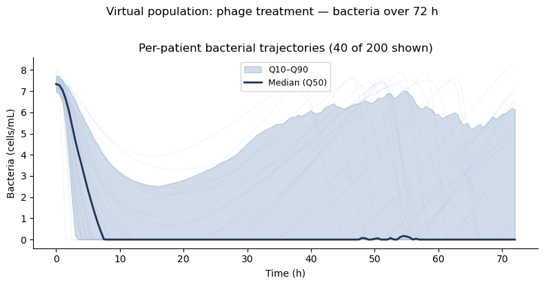

```python
# 1. Spaghetti + quantile ribbon
fig, ax = plot_trajectories(trial, compartments=("B",), n_spaghetti=40)
ax.set(ylabel="Bacteria (cells/mL)",
       title="Per-patient bacterial trajectories (40 of 200 shown)")
plt.suptitle("Virtual population: phage treatment — bacteria over 72 h", y=1.02)
plt.tight_layout()
plt.show()
```

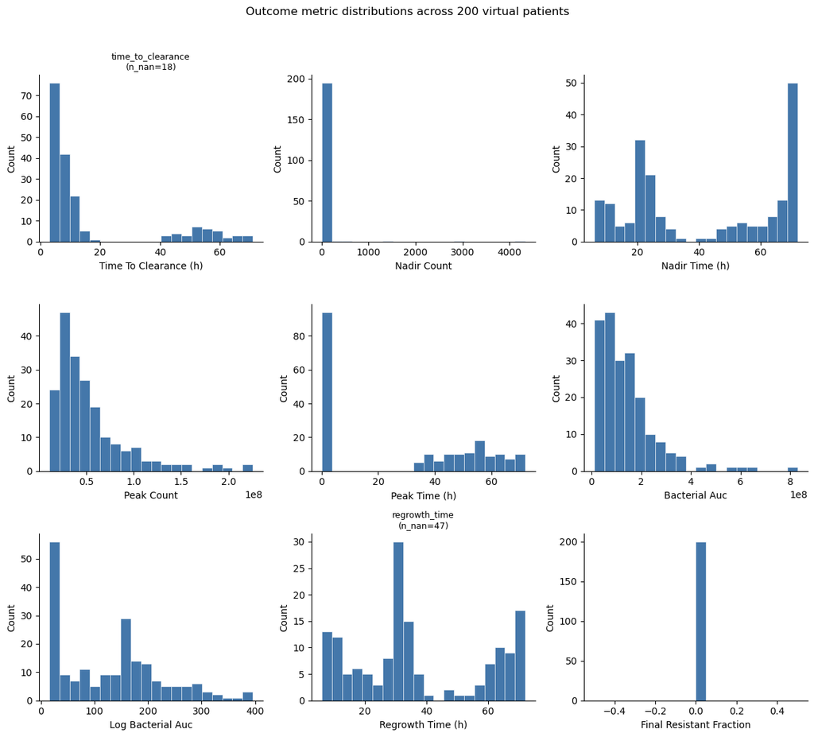

```python
# 2. Metric distributions
fig, axes = plot_metric_distributions(trial)
plt.suptitle("Outcome metric distributions across 200 virtual patients", y=1.02)
plt.tight_layout()
plt.show()
```

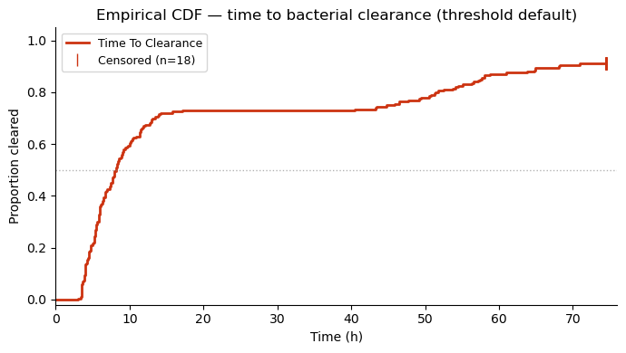

```
Patients achieving clearance: 182 / 200 (91.0%)
Median time to clearance: 7.7 h
```

```python
# 3. Time-to-event (clearance) CDF
fig, ax = plot_time_to_event(trial, metric="time_to_clearance")
ax.set(xlabel="Time (h)", ylabel="Proportion cleared",
       title="Empirical CDF — time to bacterial clearance (threshold default)")
plt.tight_layout()
plt.show()

n_total = trial.n_succeeded + trial.n_failed
n_cleared = trial.metrics["time_to_clearance"].notna().sum()
print(f"Patients achieving clearance: {n_cleared} / {n_total} "
      f"({100*n_cleared/n_total:.1f}%)")
print(f"Median time to clearance: {trial.metrics['time_to_clearance'].median():.1f} h")
```

## 7 Summary

| Object | Role |
| --- | --- |
| `IIVSpec({path: (dist, transform), ...})` | Map parameter paths to variability distributions |
| `InitialConditions(B=..., P=..., S=...)` | Central initial values for the virtual population |
| `VirtualPopulation(cfg, iiv, n_patients, seed)` | Sample n patient-specific configs |
| `TrialRunner(vpop, model_fn, t_end, dt, metric_fns)` | Run all patients in parallel |
| `trial.metrics` | DataFrame (n_patients × n_metrics) |
| `plot_trajectories(trial)` | Spaghetti + quantile ribbon |
| `plot_metric_distributions(trial)` | Metric histograms |
| `plot_time_to_event(trial, metric)` | Empirical CDF |

**Key insight:** IIV modelling allows estimation of *how likely* a given treatment is to succeed across a realistic patient population — a more clinically relevant question than the outcome for a single nominal patient.

**Next tutorial:** *Multi-arm clinical trials* — comparing treatment arms (control, phage, phage + antibiotic) over the same virtual patient population using the matched-twins design.